# CFA: Basics

# Confirmatory Factor Analysis

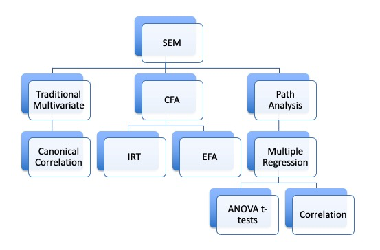

# Relation to EFA

- You have a bunch of questions
- You have an idea (or sometimes not!) of how many factors to expect
- You let the questions go where they want
- You remove the bad questions until you get a good fit

# CFA models

- You set up the model with specific questions onto specific factors
- Forcing the cross loadings be zero
- You test to see if that model fits
- So, you may think about how confirmatory factor analysis is step two to exploring (exploratory factor analysis)

# CFA Models

- Reflective – the latent variable causes the manifest variables scores
- Purpose is to understand the relationships between the measured variables
- Same theoretical concept as EFA

# CFA Models Reflective Example

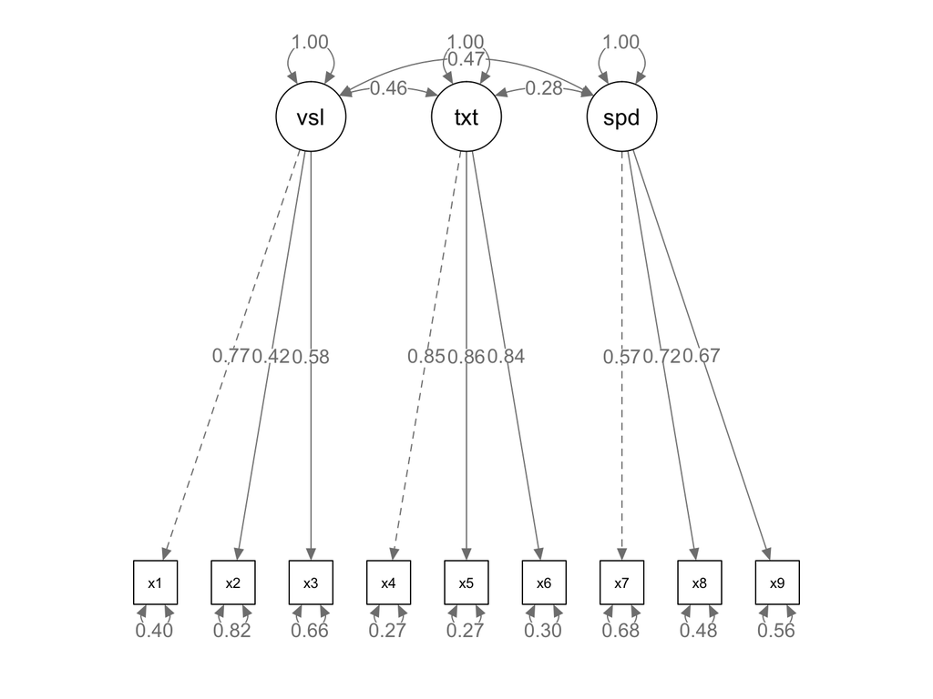

```r
# a famous example, build the model
HS.model <- ' visual  =~ x1 + x2 + x3
              textual =~ x4 + x5 + x6
              speed   =~ x7 + x8 + x9 '

# fit the model
HS.fit <- cfa(HS.model, data = HolzingerSwineford1939)

# diagram the model
semPaths(HS.fit,
         whatLabels = "std",
         layout = "tree",
         edge.label.cex = 1)
```

# CFA Models

- Formative – latent variables are the result of manifest variables
- Similar to principal components analysis theoretical concept
- Potentially a use for demographics?

# CFA Models Formative Example

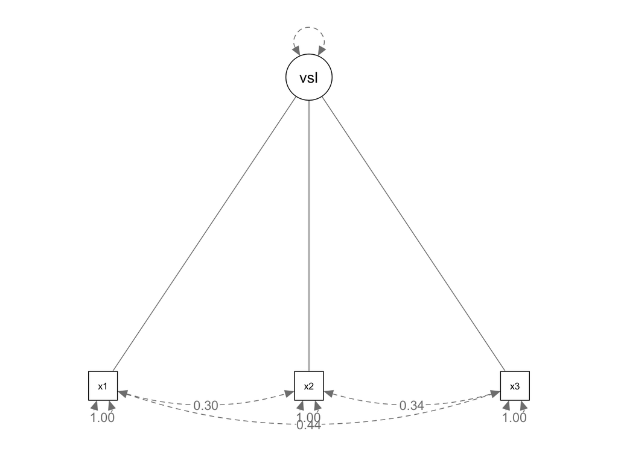

```r
# a famous example, build the model
HS.model <- ' visual  <~ x1 + x2 + x3'

# fit the model
HS.fit <- cfa(HS.model, data = HolzingerSwineford1939)
# diagram the model
semPaths(HS.fit,
         whatLabels = "std",
         layout = "tree",
         edge.label.cex = 1)
```

# CFA Models

- The manifest variables in a CFA are sometimes called indicator variables
- Because they indicate what the latent variable should be since we do not directly measure the latent variable

# General Set Up

- The latents will be correlated (because they are exogenous only)
- Similar to an oblique rotation
- Each factor section has to be identified
  - You should have three measured variables per latent
  - If you only have two, you need to set their coefficients to equal (estimated but equal)
- Arrows go from latent to measured (reflexive)
  - We think that latent caused the measured answers
- Error terms on the measured variables, variance on the latent variables
  - If you are counting for degrees of freedom for identification

# Correlated Error

- Generally, you leave the error terms uncorrelated, as you think they are separate items
- However:
- These questions all measure the same factor right?
- Often they are pretty similar
- Some answers will be related to other items
- So it’s not too big of a idea to say that item’s errors are related
- We can use modification indices to see if they should be correlated
  - Make sure these make sense!

# Interpretation

- The latent variable section includes the `factor loadings` or coefficients
- These are the same idea as EFA - you want the relationship between the latent variable and the manifest variable to be strong
  - We used a rule of .300 before but for this rule, you should examine the standardized loading
  - Otherwise, why would we think this item measures the latent variable?

# Interpretation

- These coefficients are often called:
- Pattern coefficients (unstandardized): for every one unit in the latent variable, the manifest variable increases *b* units
- Structure coefficients (standardized): the correlation between the latent variable and the manifest variable

# Identification Rules of Thumb:

- Latent variables should have four indicators
- Latent variables have three indicators AND error variances do not covary
- Latent variables have two indicators AND Error variances do not covary AND loadings are set to equal each other

# Scaling

- Remember that scaling is the way we “set the scale” for the latent variable
- We usually do this by setting one of the pattern coefficients to 1 - the marker variable approach
- Another option is to to set the variance of the latent variable to 1 `std.lv` in the the standardized output
  - What does that do?
  - Sets the scale to z-score
  - Makes double headed arrow between latents correlation
  - Make sure you are using unstandardized data!

# Scaling

- So what is the `std.all` as part of the "completely standardized solution?
- Both the latent variable variance and the manifest variable variance is set to 1
- If you are going to report the standardized solution, this version is the most common, as it matches EFA and regression
- All of these options give you different loadings, but should not change model fit

# Examples

- Reminder:
- When you use a correlation matrix as your input, the solution is already standardized!
- When you use a covariance matrix as your input, both the unstandardized and standardized solution can be viewed

# One-Factor CFA Example

- IQ is often thought of as “g” or this overall cognitive ability
- Let’s look at an example of the WISC, which is an IQ test for children
- We have five of the subtest scores including `information`, `similarities`, `word reasoning`, `matrix reasoning`, and `picture concepts`

# Convert Correlations to Covariance

```r
wisc4.cor <- lav_matrix_lower2full(c(1,
                                     0.72,1,
                                     0.64,0.63,1,
                                     0.51,0.48,0.37,1,
                                     0.37,0.38,0.38,0.38,1))
# enter the SDs
wisc4.sd <- c(3.01 , 3.03 , 2.99 , 2.89 , 2.98)

# give everything names
colnames(wisc4.cor) <-
  rownames(wisc4.cor) <-
  names(wisc4.sd) <-
  c("Information", "Similarities",
    "Word.Reasoning", "Matrix.Reasoning", "Picture.Concepts")

# convert
wisc4.cov <- cor2cov(wisc4.cor, wisc4.sd)
```

# WISC One-Factor Model

- The `=~` is used to define a reflexive latent variable
- `~` can be interpreted as Y is predicted by X
- `=~` can be interpreted as X is indicated by Ys

```r
wisc4.model <- '
g =~ Information + Similarities + Word.Reasoning + Matrix.Reasoning + Picture.Concepts
'
```

# Analyze the Model

- Notice we changed to the `cfa()` function
- It has the same basic arguments
- The `std.lv` option can be used to only see the standardized solution on the latent variable, usually you want to set this to `FALSE`

```r
wisc4.fit <- cfa(model = wisc4.model,
                sample.cov = wisc4.cov,
                sample.nobs = 550,
                std.lv = FALSE)
```

# Summarize the Model

- Logical solution:
  - Positive variances
  - SMCs + Correlations < 1
  - No error messages
  - SEs are not “huge”
- Estimates:
  - Do our questions load appropriately?
- Model fit:
  - What do the fit indices indicate?
  - Can we improve model fit without overfitting?

# Summarize the Model

```r
summary(wisc4.fit,
        standardized=TRUE,
        rsquare = TRUE,
        fit.measures=TRUE)
```

```
#> lavaan 0.6-7 ended normally after 30 iterations
#>
#>   Estimator                                         ML
#>   Optimization method                           NLMINB
#>   Number of free parameters                         10
#>
#>   Number of observations                           550
#>
#> Model Test User Model:
#>
#>   Test statistic                                26.775
#>   Degrees of freedom                                 5
#>   P-value (Chi-square)                           0.000
#>
#> Model Test Baseline Model:
#>
#>   Test statistic                              1073.427
#>   Degrees of freedom                                10
#>   P-value                                        0.000
#>
#> User Model versus Baseline Model:
#>
#>   Comparative Fit Index (CFI)                    0.980
#>   Tucker-Lewis Index (TLI)                       0.959
#>
#> Loglikelihood and Information Criteria:
#>
#>   Loglikelihood user model (H0)              -6378.678
#>   Loglikelihood unrestricted model (H1)      -6365.291
#>
#>   Akaike (AIC)                               12777.357
#>   Bayesian (BIC)                             12820.456
#>   Sample-size adjusted Bayesian (BIC)        12788.712
#>
#> Root Mean Square Error of Approximation:
#>
#>   RMSEA                                          0.089
#>   90 Percent confidence interval - lower         0.058
#>   90 Percent confidence interval - upper         0.123
#>   P-value RMSEA <= 0.05                          0.022
```

[output cut: 35 more lines]

```
#>    Std.lv  Std.all
#>     2.395    0.265
#>     2.709    0.296
#>     4.009    0.449
#>     5.551    0.666
#>     6.909    0.779
#>     1.000    1.000
#>
#> R-Square:
#>                    Estimate
#>     Information       0.735
#>     Similarities      0.704
#>     Word.Reasoning    0.551
#>     Matrix.Reasnng    0.334
#>     Picture.Cncpts    0.221
```

# New Functions

- `std.nox`: the standardized estimates are based on both the variances of both (continuous) observed and latent variables, but not the variances of exogenous covariates
- This output is the best way to get the confidence intervals for each parameter

```r
parameterestimates(wisc4.fit,
                   standardized=TRUE)
```

```
#>                 lhs op              rhs   est    se
#> 1                 g =~      Information 1.000 0.000
#> 2                 g =~     Similarities 0.985 0.045
#> 3                 g =~   Word.Reasoning 0.860 0.045
#> 4                 g =~ Matrix.Reasoning 0.647 0.047
#> 5                 g =~ Picture.Concepts 0.542 0.050
#> 6       Information ~~      Information 2.395 0.250
#> 7      Similarities ~~     Similarities 2.709 0.258
#> 8    Word.Reasoning ~~   Word.Reasoning 4.009 0.295
#> 9  Matrix.Reasoning ~~ Matrix.Reasoning 5.551 0.360
#> 10 Picture.Concepts ~~ Picture.Concepts 6.909 0.434
#> 11                g ~~                g 6.648 0.564
#>         z pvalue ci.lower ci.upper std.lv std.all std.nox
#> 1      NA     NA    1.000    1.000  2.578   0.857   0.857
#> 2  21.708      0    0.896    1.074  2.541   0.839   0.839
#> 3  18.952      0    0.771    0.949  2.217   0.742   0.742
#> 4  13.896      0    0.556    0.739  1.669   0.578   0.578
#> 5  10.937      0    0.445    0.640  1.398   0.470   0.470
#> 6   9.587      0    1.906    2.885  2.395   0.265   0.265
#> 7  10.482      0    2.202    3.215  2.709   0.296   0.296
#> 8  13.600      0    3.431    4.587  4.009   0.449   0.449
#> 9  15.400      0    4.845    6.258  5.551   0.666   0.666
#> 10 15.922      0    6.058    7.759  6.909   0.779   0.779
#> 11 11.788      0    5.543    7.754  1.000   1.000   1.000
```

# New Functions

```r
fitted(wisc4.fit) ## estimated covariances
```

```
#> $cov
#>                  Infrmt Smlrts Wrd.Rs Mtrx.R Pctr.C
#> Information      9.044
#> Similarities     6.551  9.164
#> Word.Reasoning   5.716  5.633  8.924
#> Matrix.Reasoning 4.303  4.241  3.700  8.337
#> Picture.Concepts 3.606  3.553  3.100  2.334  8.864
```

```r
wisc4.cov ## actual covariances
```

```
#>                  Information Similarities Word.Reasoning
#> Information         9.060100     6.566616       5.759936
#> Similarities        6.566616     9.180900       5.707611
#> Word.Reasoning      5.759936     5.707611       8.940100
#> Matrix.Reasoning    4.436439     4.203216       3.197207
#> Picture.Concepts    3.318826     3.431172       3.385876
#>                  Matrix.Reasoning Picture.Concepts
#> Information              4.436439         3.318826
#> Similarities             4.203216         3.431172
#> Word.Reasoning           3.197207         3.385876
#> Matrix.Reasoning         8.352100         3.272636
#> Picture.Concepts         3.272636         8.880400
```

# All Fit Indices

```r
fitmeasures(wisc4.fit)
```

```
#>                npar                fmin
#>              10.000               0.024
#>               chisq                  df
#>              26.775               5.000
#>              pvalue      baseline.chisq
#>               0.000            1073.427
#>         baseline.df     baseline.pvalue
#>              10.000               0.000
#>                 cfi                 tli
#>               0.980               0.959
#>                nnfi                 rfi
#>               0.959               0.950
#>                 nfi                pnfi
#>               0.975               0.488
#>                 ifi                 rni
#>               0.980               0.980
#>                logl   unrestricted.logl
#>           -6378.678           -6365.291
#>                 aic                 bic
#>           12777.357           12820.456
#>              ntotal                bic2
#>             550.000           12788.712
#>               rmsea      rmsea.ci.lower
#>               0.089               0.058
#>      rmsea.ci.upper        rmsea.pvalue
#>               0.123               0.022
#>                 rmr          rmr_nomean
#>               0.298               0.298
#>                srmr        srmr_bentler
#>               0.034               0.034
#> srmr_bentler_nomean                crmr
#>               0.034               0.042
#>         crmr_nomean          srmr_mplus
#>               0.042               0.034
#>   srmr_mplus_nomean               cn_05
#>               0.034             228.408
#>               cn_01                 gfi
#>             310.899               0.982
#>                agfi                pgfi
#>               0.947               0.327
#>                 mfi                ecvi
#>               0.980               0.085
```

# Modification Indices

```r
modificationindices(wisc4.fit, sort = T)
```

```
#>                 lhs op              rhs     mi    epc
#> 21 Matrix.Reasoning ~~ Picture.Concepts 14.157  1.058
#> 19   Word.Reasoning ~~ Matrix.Reasoning  8.931 -0.710
#> 15      Information ~~ Picture.Concepts  5.493 -0.565
#> 20   Word.Reasoning ~~ Picture.Concepts  2.029  0.365
#> 14      Information ~~ Matrix.Reasoning  1.447  0.280
#> 18     Similarities ~~ Picture.Concepts  0.838 -0.223
#> 16     Similarities ~~   Word.Reasoning  0.791  0.242
#> 13      Information ~~   Word.Reasoning  0.279  0.147
#> 17     Similarities ~~ Matrix.Reasoning  0.147 -0.089
#> 12      Information ~~     Similarities  0.010  0.034
#>    sepc.lv sepc.all sepc.nox
#> 21   1.058    0.171    0.171
#> 19  -0.710   -0.151   -0.151
#> 15  -0.565   -0.139   -0.139
#> 20   0.365    0.069    0.069
#> 14   0.280    0.077    0.077
#> 18  -0.223   -0.051   -0.051
#> 16   0.242    0.073    0.073
#> 13   0.147    0.047    0.047
#> 17  -0.089   -0.023   -0.023
#> 12   0.034    0.013    0.013
```

# Diagram the Model

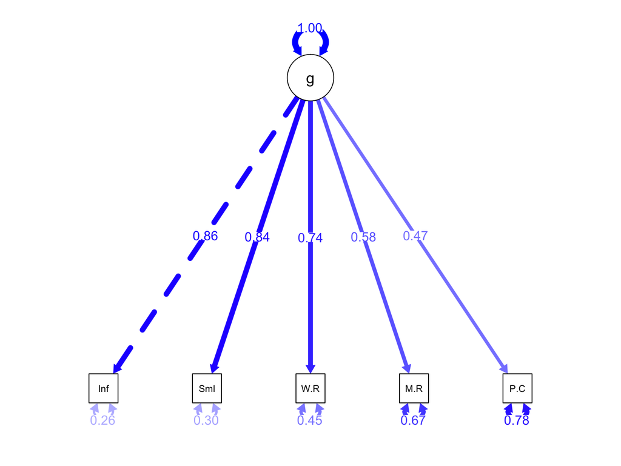

```r
semPaths(wisc4.fit,
         whatLabels="std",
         what = "std",
         layout ="tree",
         edge.color = "blue",
         edge.label.cex = 1)
```

# WISC Two-Factor Model

- Note that we only have two items on the latent variable
- If we see an identification error, we can set these to equal (homework hint!)

```r
wisc4.model2 <- '
V =~ Information + Similarities + Word.Reasoning
F =~ Matrix.Reasoning + Picture.Concepts
'

# wisc4.model2 <- '
# V =~ Information + Similarities + Word.Reasoning
# F =~ a*Matrix.Reasoning + a*Picture.Concepts
# '
```

# Analyze the Model

```r
wisc4.fit2 <- cfa(wisc4.model2,
                  sample.cov=wisc4.cov,
                  sample.nobs=550,
                  std.lv = F)
```

# Summarize the Model

```r
summary(wisc4.fit2,
        standardized=TRUE,
        rsquare = TRUE,
        fit.measures=TRUE)
```

```
#> lavaan 0.6-7 ended normally after 44 iterations
#>
#>   Estimator                                         ML
#>   Optimization method                           NLMINB
#>   Number of free parameters                         11
#>
#>   Number of observations                           550
#>
#> Model Test User Model:
#>
#>   Test statistic                                12.687
#>   Degrees of freedom                                 4
#>   P-value (Chi-square)                           0.013
#>
#> Model Test Baseline Model:
#>
#>   Test statistic                              1073.427
#>   Degrees of freedom                                10
#>   P-value                                        0.000
#>
#> User Model versus Baseline Model:
#>
#>   Comparative Fit Index (CFI)                    0.992
#>   Tucker-Lewis Index (TLI)                       0.980
#>
#> Loglikelihood and Information Criteria:
#>
#>   Loglikelihood user model (H0)              -6371.634
#>   Loglikelihood unrestricted model (H1)      -6365.291
#>
#>   Akaike (AIC)                               12765.269
#>   Bayesian (BIC)                             12812.678
#>   Sample-size adjusted Bayesian (BIC)        12777.759
#>
#> Root Mean Square Error of Approximation:
#>
#>   RMSEA                                          0.063
#>   90 Percent confidence interval - lower         0.026
#>   90 Percent confidence interval - upper         0.103
#>   P-value RMSEA <= 0.05                          0.244
```

[output cut: 47 more lines]

```
#>     2.352    0.260
#>     2.685    0.293
#>     4.000    0.448
#>     4.380    0.525
#>     6.168    0.696
#>     1.000    1.000
#>     1.000    1.000
#>
#> R-Square:
#>                    Estimate
#>     Information       0.740
#>     Similarities      0.707
#>     Word.Reasoning    0.552
#>     Matrix.Reasnng    0.475
#>     Picture.Cncpts    0.304
```

# Diagram the Model

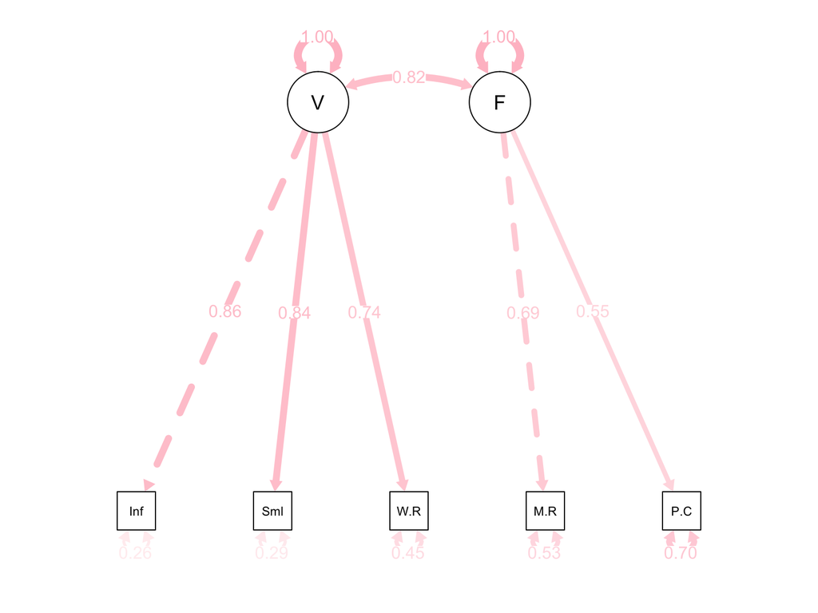

```r
semPaths(wisc4.fit2,
         whatLabels="std",
         what = "std",
         edge.color = "pink",
         edge.label.cex = 1,
         layout="tree")
```

# Compare the Models

```r
anova(wisc4.fit, wisc4.fit2)
```

```
#> Chi-Squared Difference Test
#>
#>            Df   AIC   BIC  Chisq Chisq diff Df diff
#> wisc4.fit2  4 12765 12813 12.687
#> wisc4.fit   5 12777 12820 26.775     14.088       1
#>            Pr(>Chisq)
#> wisc4.fit2
#> wisc4.fit   0.0001745 ***
#> ---
#> Signif. codes:
#> 0 '***' 0.001 '**' 0.01 '*' 0.05 '.' 0.1 ' ' 1
```

```r
fitmeasures(wisc4.fit, c("aic", "ecvi"))
```

```
#>       aic      ecvi
#> 12777.357     0.085
```

```r
fitmeasures(wisc4.fit2, c("aic", "ecvi"))
```

```
#>       aic      ecvi
#> 12765.269     0.063
```

# How to Tidy lavaan Output

- https://easystats.github.io/parameters/articles/efa_cfa.html

```r
#install.packages("parameters")
library(parameters)
model_parameters(wisc4.fit, standardize = TRUE)
```

```
#> # Loading
#>
#> Link                  | Coefficient |   SE |       95% CI |      p
#> ------------------------------------------------------------------
#> g =~ Information      |        0.86 | 0.02 | [0.82, 0.89] | < .001
#> g =~ Similarities     |        0.84 | 0.02 | [0.80, 0.87] | < .001
#> g =~ Word.Reasoning   |        0.74 | 0.02 | [0.70, 0.79] | < .001
#> g =~ Matrix.Reasoning |        0.58 | 0.03 | [0.52, 0.64] | < .001
#> g =~ Picture.Concepts |        0.47 | 0.04 | [0.40, 0.54] | < .001
```

# How to Tidy lavaan Output

```r
library(broom)
tidy(wisc4.fit)
```

```
#> # A tibble: 11 x 9
#>    term  op    estimate std.error statistic p.value std.lv
#>    <chr> <chr>    <dbl>     <dbl>     <dbl>   <dbl>  <dbl>
#>  1 g =~… =~       1        0          NA         NA   2.58
#>  2 g =~… =~       0.985    0.0454     21.7        0   2.54
#>  3 g =~… =~       0.860    0.0454     19.0        0   2.22
#>  4 g =~… =~       0.647    0.0466     13.9        0   1.67
#>  5 g =~… =~       0.542    0.0496     10.9        0   1.40
#>  6 Info… ~~       2.40     0.250       9.59       0   2.40
#>  7 Simi… ~~       2.71     0.258      10.5        0   2.71
#>  8 Word… ~~       4.01     0.295      13.6        0   4.01
#>  9 Matr… ~~       5.55     0.360      15.4        0   5.55
#> 10 Pict… ~~       6.91     0.434      15.9        0   6.91
#> 11 g ~~… ~~       6.65     0.564      11.8        0   1.00
#> # … with 2 more variables: std.all <dbl>, std.nox <dbl>
```

```r
glance(wisc4.fit)
```

```
#> # A tibble: 1 x 17
#>    agfi    AIC    BIC   cfi chisq  npar  rmsea
#>   <dbl>  <dbl>  <dbl> <dbl> <dbl> <dbl>  <dbl>
#> 1 0.947 12777. 12820. 0.980  26.8    10 0.0890
#> # … with 10 more variables: rmsea.conf.high <dbl>,
#> #   srmr <dbl>, tli <dbl>, converged <lgl>,
#> #   estimator <chr>, ngroups <int>, missing_method <chr>,
#> #   nobs <dbl>, norig <dbl>, nexcluded <dbl>
```

# Summary

- In this lecture you’ve learned:
  - How to create a simple confirmatory factor analysis (measurement model)
  - How to view parameter estimates, modification indices, and more
  - Practiced building these models and comparing them